# Relatório - Celular Global HATCO: Perfil do Consumidor

[figure not shown]

### Bianca Fernandes Batista e Renata Lourenço Richter

#### Curso: Administração Pública

#### Disciplina: Estatística Aplicada às Ciências Humanas e Sociais

#### Professor: Steven Dutt Ross

### 06-10-2017

**Introdução:**

Por meio deste relatório, procura-se traçar o perfil do consumidor da Celular Global HATCO para permitir um estabelecimento de estratégias de marketing mais eficiente. Este será dividido em objetivos, metodologia, resultados e conclusão.

**Objetivos:**

Traçar o perfil do consumidor quanto ao/à:  
*Público já alcançado;  
*Produto de sucesso mais expressivo;  
*Satisfação relacionada ao serviço em geral fornecido pela empresa (desde o produto até seu serviço de entrega).

**Metodologia:**

A base de dados utilizada para análise e compreensão do perfil do consumidor da Celular Global HATCO foi montada a partir de dados obtidos através de um questionário. Este foi entregue a um cliente cada vez que uma compra foi realizada, seja online ou em loja física. Nele havia perguntas relacionadas a 14 variáveis, sendo 5 qualitativas - pedindo a escolha da opção na qual o consumidor se encaixava melhor - e 9 qualitativas - pedindo para avaliar as variáveis através de notas com mínimo e máximo indicado.  
A partir dessa base de dados, combinar-se-ão as variáveis através de estatísticas e gráficos por intermédio do R project, buscando chegar aos objetivos anteriormente citados. Portanto, estes serão guias para a escolha de combinações e comparações a serem feitas.  
Em seguida, será feita uma análise, possibilitanto o esclarecimento dos resultados encontrados em cada estatística e gráfico. E a partir deles, utilizando juntamente conhecimentos administrativos acerca do marketing, serão formuladas estratégias a serem seguidas pela empresa.

**Resultados:**

```r
> summary(HATCO)
```

```
       ID         Velocidade_de_entrega Preço_do_produto
 Min.   :  1.00   Min.   :0.000         Min.   :0.200
 1st Qu.: 25.75   1st Qu.:2.500         1st Qu.:1.475
 Median : 50.50   Median :3.400         Median :2.150
 Mean   : 50.50   Mean   :3.515         Mean   :2.364
 3rd Qu.: 75.25   3rd Qu.:4.600         3rd Qu.:3.225
 Max.   :100.00   Max.   :6.100         Max.   :5.400
 Flexibilidade_de_preços Imagem_do_fabricante Avaliação_da_embalagem
 Min.   : 5.000          Min.   :2.500        Min.   :0.700
 1st Qu.: 6.700          1st Qu.:4.575        1st Qu.:2.400
 Median : 8.050          Median :5.000        Median :3.000
 Mean   : 7.894          Mean   :5.248        Mean   :2.916
 3rd Qu.: 9.100          3rd Qu.:6.000        3rd Qu.:3.425
 Max.   :10.000          Max.   :8.200        Max.   :4.600
 Imagem_da_força_de_vendas Qualidade_do_produto Tamanho_da_empresa
 Min.   :1.100             Min.   : 3.700       Pequena:60
 1st Qu.:2.200             1st Qu.: 5.800       Grande :40
 Median :2.600             Median : 7.150
 Mean   :2.665             Mean   : 6.971
 3rd Qu.:3.000             3rd Qu.: 8.325
 Max.   :4.600             Max.   :10.000
  Nível_de_uso   Nível_de_satisfação               Internet
 Min.   :25.00   Min.   :3.200       Usuário eventual  :40
 1st Qu.:39.00   1st Qu.:4.100       Usuário acostumado:60
 Median :46.50   Median :4.850
 Mean   :46.10   Mean   :4.771
 3rd Qu.:53.25   3rd Qu.:5.400
 Max.   :65.00   Max.   :6.800
 Faixa_de_idade        Sexo                Local_da_compra
 Jovem :50      Masculino:50   Capital             :34
 Adulto:50      Feminino :50   Região metropolitana:32
                               Interior            :34
```

##### Parte 1: Qualitativa X Qualitativa

```r
> with(HATCO, Barplot(Faixa_de_idade, by=Sexo, style="parallel", legend.pos="top",
+   xlab="Faixa de idade", ylab="Frequência", col=c("#f9cc8b","#f3fc94")))
```

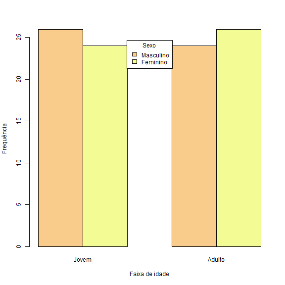

```r
> local({
+   .Table <- xtabs(~Internet+Faixa_de_idade, data=HATCO)
+   cat("\nFrequency table:\n")
+   print(.Table)
+   .Test <- chisq.test(.Table, correct=FALSE)
+   print(.Test)
+ })
```

Através desta tabela, observa-se que 80% do público adulto é usuário eventual da internet, enquanto 100% do público jovem já é acostumado com ela.  
Considerando o total dentre os consumidores, 60% está habituado ao ambiente virtual. Todavia ainda há porcentagem expressiva de consumidores sem afinidade com esta.

[figure not shown]

##### Parte 2: Quantitativa X Qualitativa

```r
> Boxplot(Velocidade_de_entrega~Internet, data=HATCO, id.method="y",
+   ylab="Velocidade de entrega", col=c("#b1fc94","#71bfc6"))
```

Segundo a base de dados fornecida pelo setor de pesquisa aplicada, as vendas através da internet agregam dois tipos de usuários. O usuário eventual é aquele não habituado com a compra de produtos por meio da internet e o usuário acostumado, ao contrário, faz uso frequente desse meio virtual. Desse modo, é pertinente ressaltar que o usuário tido como acostumado têm maior conhecimento sobre a variável “velocidade de entrega” e, por isso, a opinião desse público, representada no boxplot a seguir, é de extrema importância para o sucesso da empresa.  
Nesse boxplot, percebe-se uma diferença grande dentre as medianas do usuário eventual e do usuário acostumado. O primeiro, dá notas menores, tendo sua mediana localizada por volta de 2,5, e possue os primeiro e terceiro quartis mais concentrados. Este grupo ainda apresenta dois outliers, sendo que o 57 avalia a velocidade de entrega da HATCO com valor próximo de 5 e o consumidor 39 avalia como 0.  
O segundo grupo, já tem uma avaliação mais positiva com relação à rapidez das entregas da compania, tendo mediana próxima de 4,2. Nesse, a distribuição dos quartis é mais simétrica e não há outliers. Apesar de o usuário acostumado avaliar a organização com notas mais elevadas do que o usuário eventual, ele ainda fornece valores muito baixos para a velocidade de entrega da empresa, tendo seu máximo em 6,1.

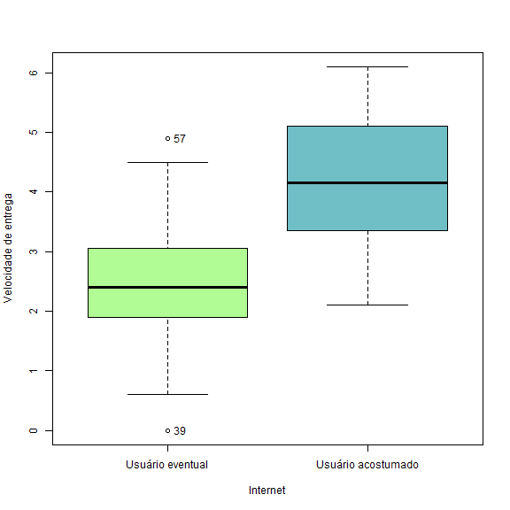

```
[1] "39" "57"
```

```r
> Boxplot(Preço_do_produto~Faixa_de_idade, data=HATCO, id.method="y",
+   xlab="Faixa de Idade", ylab="Preço do produto", col=c("skyblue","darkblue"))
```

O boxplot a seguir relaciona duas variáveis: faixa de idade, que admite dois públicos - o jovem e o adulto -, e a variável preço dos produtos em uma escala de 0 a 6 - sendo os produtos considerados mais baratos com pontuação próxima a 0 e os mais caros próxima a 6.  
A parte que representa o público jovem possui menor variância quanto ao julgamento dos preços dos produtos, permanecendo o primeiro quartil, a mediana e o terceiro quartil na faixa de preço considerada barata, isto é, abaixo de 3, com notas entre 0,2 e 2,15.  
Em contrapartida, o público adulto é representado por um boxplot com maior variância. Este grupo, avalia os produtos desde consideravelmente baratos - tendo seu mínimo por volta de 1 - a bem caros, com máxima 5,4. Sua mediana de 3,2 mostra que 50% dos adultos consideram os produtos com preços relativamente baixos.  
A percepção dos preços pelos consumidores, em geral, apresenta-se positiva em ambos os grupos pelas baixas notas dadas aos preços dos produtos.

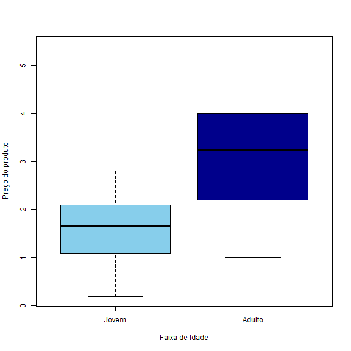

```r
> Boxplot(Qualidade_do_produto~Tamanho_da_empresa, data=HATCO, id.method="y",
+   xlab="Tamanho da empresa", ylab="Qualidade do produto", col=c("#a9a8ff","#885ea0"))
```

Com o objetivo de verificar se há uniformidade ou não na qualidade do produto oferecido de acordo com o tamanho da empresa fornecedora, foi criado um gráfico Boxplot a partir da base de dados gerada pelo setor de pesquisa aplicada.  
As empresas classificadas como de pequeno porte possuem maior variância na qualidade de produtos oferecidos, classificados com nota de 0 a 10. Sendo notas próximas de 0 produtos de baixa qualidade e nota 10 como alta qualidade. As empresas de pequeno porte receberam nota mínima de 3,70 na qualidade dos produtos, mediana assumindo o valor de 6,20 e como nota máxima 8,6. Constatando assim a maior variância.  
Já as classificadas como de grande porte apresentam menor variância na qualidade dos produtos, oferecem, de maneira geral, produtos classificados como de alta qualidade, com notas concentradas de 7,70 a 8,80 (primeiro quartil e terceiro quartil,respectivamente) e com nota máxima em aproximadamente 10.  
Por fim,não há uniformidade na qualidade dos produtos oferecidos, estes variando de acordo com o porte da empresa.

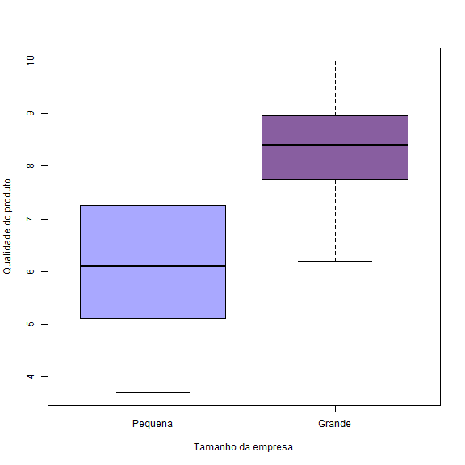

```r
> Boxplot(Velocidade_de_entrega~Local_da_compra, data=HATCO, id.method="y",
+   xlab="Local da compra", ylab="Velocidade de entrega", col=c("#ff9ee6","#ff8795",
+   "darkred"))
```

Através do gráfico é possível analisar que a Capital possui uma velocidade de entrega considerada ruim, pois apresenta mediana em torno de 2,4.  
A parte do gráfico que representa a Região Metropolitana já apresenta um serviço mais rápido com sua mediana de 3,4.  
No interior, onde se esperava ter o maior tempo para entrega, é o local possuidor de maior mediana (cerca de 4,8), ou seja, da avaliação de menor tempo de entrega.  
Conclui-se assim, que a velocidade de entrega para os locais de compra é mais rápida em locais de dimensões menores, como o Interior, e mais demorada em lugares mais populosos, como a Capital.

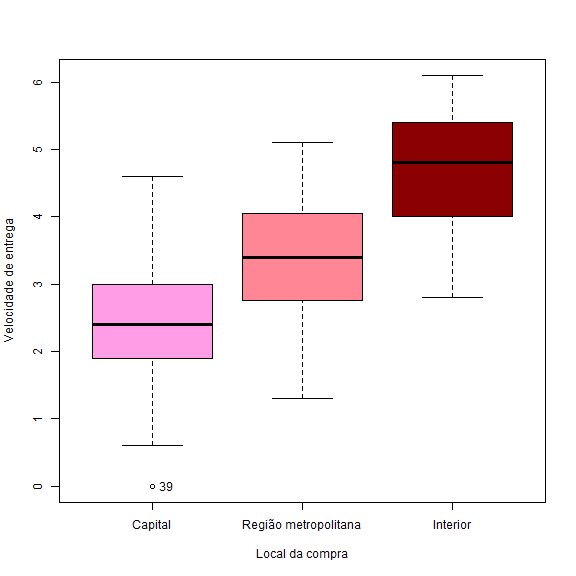

```
[1] "39"
```

##### Parte 3: Quantitativa X Quantitativa

```r
> scatterplot(Avaliação_da_embalagem~Nível_de_uso, reg.line=lm, smooth=FALSE,
+   spread=FALSE, boxplots='xy', span=0.5, ellipse=FALSE, levels=c(.5, .9), xlab="Nível
+   de
+   uso", ylab="Avaliação da
+   Embalagem", data=HATCO, pch=19, col=c("darkred",1,"#81c6af"))
```

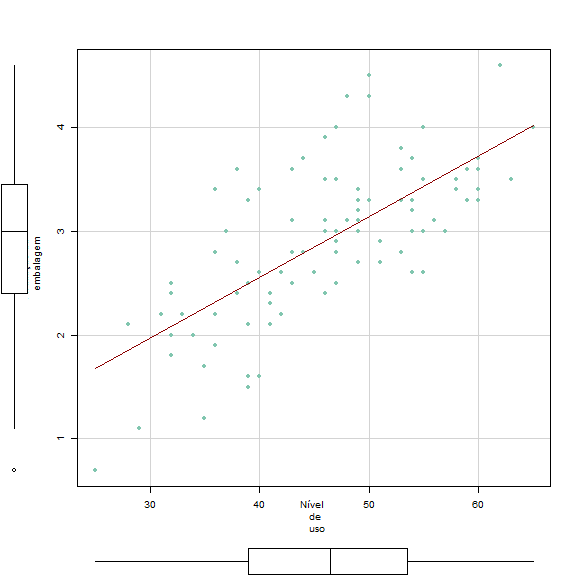

```r
> scatterplot(Nível_de_satisfação~Preço_do_produto, reg.line=lm, smooth=FALSE,
+   spread=FALSE, boxplots='xy', span=0.5, ellipse=FALSE, levels=c(.5, .9), xlab="Preço
+   do
+   produto", ylab="Nível de
+   satisfação", data=HATCO,pch=19, col=c("darkred",1,"#81c6af"))
```

Neste diagrama, são correlacionadas as variáveis “nível de satisfação” e “preço do produto”. A primeira é representada por uma nota que pode ser de 0 a 10, enquanto a segunda é uma nota que pode ir de 0 (barato) a 6(caro).  
Na situação apresentada, observa-se que, conquanto pequena, há uma correlação positiva entre as variáveis. Logo, pode-se concluir que o preço do produto não tem influência relevante o suficiente no nível de satisfação para ser levado em consideração pela empresa.

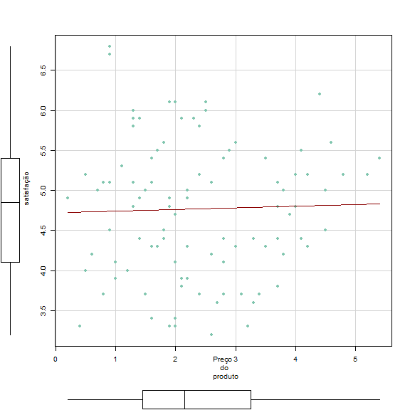

```r
> scatterplot(Qualidade_do_produto~Preço_do_produto, reg.line=lm, smooth=FALSE,
+   spread=FALSE, boxplots='xy', span=0.5, ellipse=FALSE, levels=c(.5, .9), xlab="Preço
+   do
+   produto", ylab="Qualidade do
+   produto", data=HATCO,pch=19, col=c("darkred",1,"#81c6af"))
```

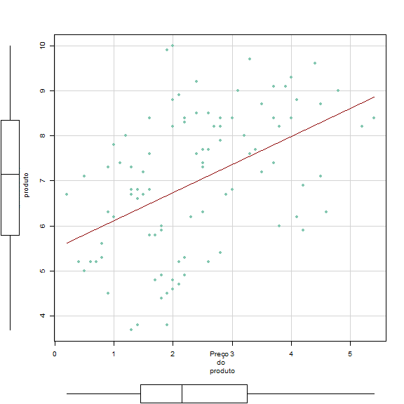

```r
> scatterplot(Qualidade_do_produto~Nível_de_satisfação, reg.line=lm, smooth=FALSE,
+   spread=FALSE, boxplots='xy', span=0.5, ellipse=FALSE, levels=c(.5, .9), xlab="Nível
+   de
+   satisfação", ylab="Qualidade do
+   produto", data=HATCO,pch=19, col=c("darkred",1,"#81c6af"))
```

O gráfico abaixo trabalha com as variáveis “qualidade do produto” e “nível de satisfação”.  
Ao contrário do que se esperaria, as variáveis possuem correlação relevante negativa, ou seja, quanto maior o nível de satisfação, menor a qualidade do produto. Isso caracteriza um resultado contraintuitivo.  
Neste momento, é possível questionar a eficácia da base de dados perguntando se de fato isso ocorre. Frente a essa situação, seria adequada a realização de outra pesquisa ao redor dos mesmos fatores.

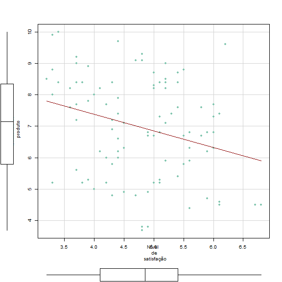

```r
> scatterplot(Nível_de_uso~Flexibilidade_de_preços, reg.line=lm, smooth=FALSE,
+   spread=FALSE, boxplots='xy', span=0.5, ellipse=FALSE, levels=c(.5, .9),
+   xlab="Flexibilidade de preços", ylab="Nível de uso", data=HATCO,pch=19,
+   col=c("darkred",1,"#81c6af"))
```

No gráfico abaixo analisam-se as variáveis “nível de uso” e “flexibilidade de preço”, sendo essa última avaliada com uma nota de 0 a 10, tendo 0 como pouco flexível e 10 muito. A flexibilidade, ainda, quer mostrar a variedade de formas de pagamento possíveis, tais como à vista, parcelado, crédito, cheque etc.  
No diagrama percebe-se uma correlação positiva e considerável entre as variáveis: quanto maior uma, maior a outra. Ademais, por intermédio dos boxplots marginais, observa-se que a mediana da flexibilidade de preços é aproximadamente 8. Esta mostra a grande flexibilidade para pagamentos dos seus clientes a Celular Global HATCO.  
Já através do outro boxplot, tem-se a mediana com valor próximo a 47, mostrando ainda um nível de uso baixo da empresa.

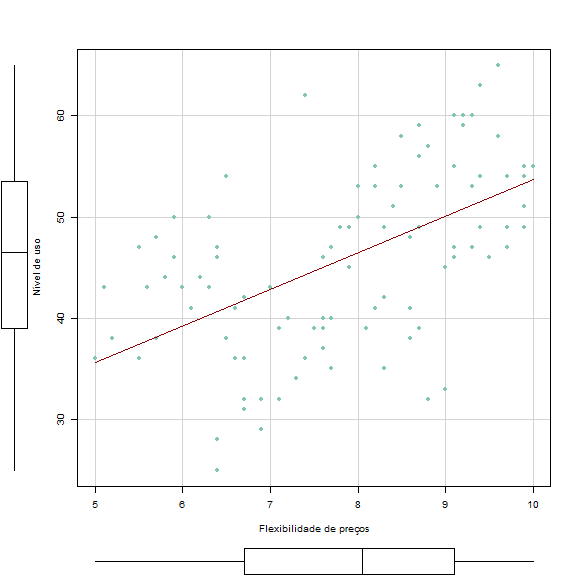

```r
HATCO <- readXL("C:/Users/Renata/Downloads/HATCO.xlsx", rownames=FALSE, header=TRUE, na="",
  sheet="HATCO", stringsAsFactors=TRUE)
```